# PSet2 Mallah

2024-01-28

```r
library(tidyverse)
library(knitr)
library(reader)
library(tibble)
library(dplyr)
library(gapminder)
```

Answer 1: https://github.com/maveenmm/PSet2.git

Answer 2: See corrections below

```r
library(tidyverse)
# open my data
gspace = read_csv('greenspace_data_share.csv') #missing quotations

# summarize average urban greenspace by region
  table =
  gspace |>
  group_by(Major_Geo_Region) |>
  summarise(
    obs = n(), #missing comma
    avg = mean(annual_avg_2020, na.rm = TRUE), #missing underscore #added na.rm = TRUE
    'weighted_avg' = mean(annual_weight_avg_2020, na.rm = TRUE) #missing underscore #missing quotations #added na.rm = TRUE
    )  |>
      rename("Weighted Average" = weighted_avg, "Major Geographical Region" = Major_Geo_Region, "Urban Areas" = obs, "Average" = avg)


# output as table
kable(table, digits = 1L #missing L
)
```

| Major Geographical Region | Urban Areas | Average | Weighted Average |
| --- | --- | --- | --- |
| Africa | 154 | 0.3 | 0.2 |
| Asia | 569 | 0.3 | 0.3 |
| Europe | 128 | 0.3 | 0.3 |
| Latin America and the Caribbean | 120 | 0.3 | 0.3 |
| Northern America | 58 | 0.3 | 0.3 |
| Oceania | 9 | 0.3 | 0.3 |

Answer 3: The greenspace data covers 1038 urban areas

```r
length(gspace$City)
```

```
## [1] 1038
```

Answer 4: This table shows the distribution of urban areas in 2021 based on their classification. The most common classification is “Low”, with 394 urban areas. There are also a significant number of urban areas classified as “Very Low” (265) and “Moderate” (215). Fewer urban areas are classified as “Exceptionally Low” (100), “High” (62), and “Very High” (1). There is also one urban area with missing data, which is classified as “NA”.

```r
library(knitr)
answer4 =
  gspace |>
count(indicator_2021) |>
rename("2021 Greenspace Classification" = indicator_2021, "Urban Areas" = n)
kable(answer4)
```

| 2021 Greenspace Classification | Urban Areas |
| --- | --- |
| Exceptionally Low | 100 |
| High | 62 |
| Low | 394 |
| Moderate | 215 |
| Very High | 1 |
| Very Low | 265 |
| NA | 1 |

Answer 5a:69 urban areas scored High or above for greenspace in 2015

```r
sum(gspace$peak_NDVI_2015 >=0.5)
```

```
## [1] 69
```

```r
library(dplyr)
answer5b= gspace|>
  filter(indicator_2010 =="Exceptionally Low",
         indicator_2015=="Exceptionally Low",
         indicator_2020=="Exceptionally Low",
         indicator_2021=="Exceptionally Low") |>
summarise(obs = n())
print(answer5b)
```

```
## # A tibble: 1 × 1
##     obs
##   <int>
## 1    71
```

Answer 5c: 225 urban areas in arid climate became green from 2010 to 2020

```r
library(dplyr)
library(knitr)
answer5c = gspace |>
  filter(Climate_region == "Arid") |>
  mutate(green = ifelse(annual_weight_avg_2020 - annual_weight_avg_2010 > 0, 'increase', 'decrease')
  )
increase = sum(answer5c$green == 'increase')
decrease = sum(answer5c$green == 'decrease')
table(increase, decrease)
```

```
##         decrease
## increase 5
##      225 1
```

Answer 6: 128 urban areas became less green from 2010 to 2021

```r
answer6 = gspace |>
  mutate(
    green = ifelse(annual_avg_2021 - annual_avg_2010 > 0, 'increase', 'decrease')
  )
table(answer6$green)
```

```
##
## decrease increase
##      128      907
```

Answer 7: See hisotrgram of change in greenspace from 2010 to 2021

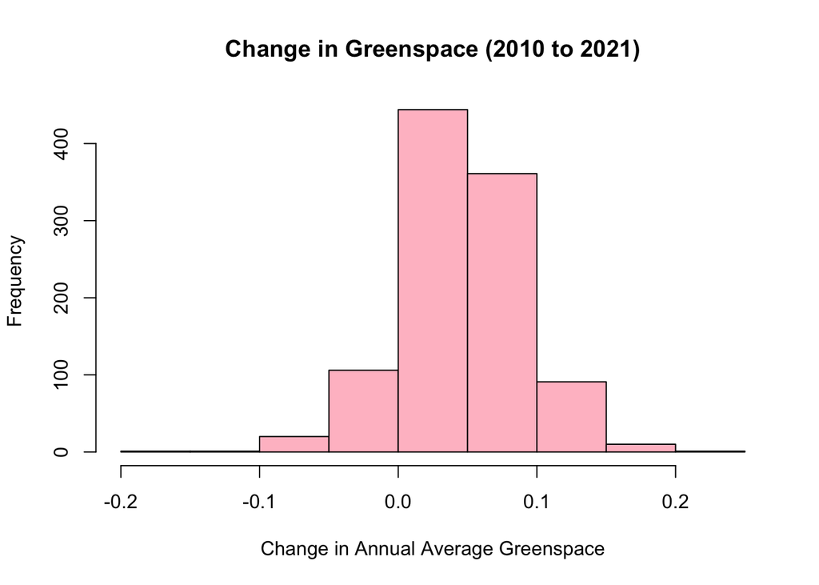

```r
gspace = gspace |>
  mutate(
    change = annual_avg_2021 - annual_avg_2010
  )
hist(gspace$change, main = "Change in Greenspace (2010 to 2021)", xlab = "Change in Annual Average Greenspace", col='pink')
```

Answer 8 + Extra Credit: See scatter plot of population weighted greenspace in 2021 over greenspace in 2010 below

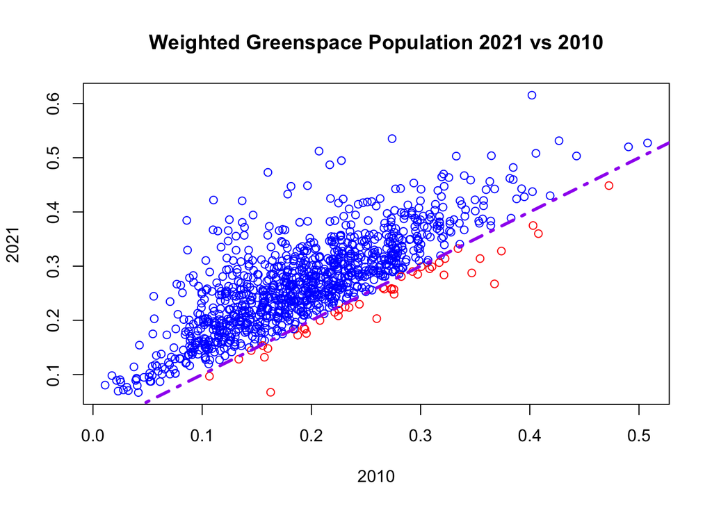

```r
gspace = gspace |>
  mutate(
    change = annual_weight_avg_2021 - annual_weight_avg_2010
  )

plot(
  gspace$annual_weight_avg_2010,
  gspace$annual_weight_avg_2021,
  main = "Weighted Greenspace Population 2021 vs 2010",
  xlab = "2010",
  ylab = "2021",
  col = ifelse(gspace$change < 0, "red", "blue")
)
abline(a = 0, b = 1, lwd = 3, lty = 4, col = "purple")
```